# main

2024-03-09

# ExData_Plotting1

This is the main R markdown file for the Exploratory Data Analysis course project 1. The goal of this project is to examine how household energy usage varies over a 2-day period in February, 2007. The data is taken from the UCI Machine Learning Repository and is available at the following link: https://d396qusza40orc.cloudfront.net/exdata%2Fdata%2Fhousehold_power_consumption.zip

The individual plots are created using functions defined in the `plot1.R`, `plot2.R`, `plot3.R`, and `plot4.R` files. The data is processed in the `main.R` file.

## Introduction

First, we will download and unzip the data. Then, we will load the data and subset it to the relevant time period. Finally, we will create the plots.

## Data Processing

```r
# Download and unzip the data
data_source <- "https://d396qusza40orc.cloudfront.net/exdata%2Fdata%2Fhousehold_power_consumption.zip"
zip_file <- "./data/household_power_consumption.zip"
file_path <- "./data/household_power_consumption.txt"

# If data directory does not exist, create it
if (!file.exists("./data")) {
    dir.create("./data")
}

# If the file does not exist, download it and unzip it
if (!file.exists(file_path)) {
    download.file(data_source, zip_file, method = "curl")
    unzip(zip_file, exdir = "./data")
}

# Load the data
data <- read.table("./data/household_power_consumption.txt", header = TRUE, sep = ";", na.strings = "?")
```

Let’s take a look at the data

```r
class(data)
```

```
## [1] "data.frame"
```

```r
head(data)
```

```
##         Date     Time Global_active_power Global_reactive_power Voltage
## 1 16/12/2006 17:24:00               4.216                 0.418  234.84
## 2 16/12/2006 17:25:00               5.360                 0.436  233.63
## 3 16/12/2006 17:26:00               5.374                 0.498  233.29
## 4 16/12/2006 17:27:00               5.388                 0.502  233.74
## 5 16/12/2006 17:28:00               3.666                 0.528  235.68
## 6 16/12/2006 17:29:00               3.520                 0.522  235.02
##   Global_intensity Sub_metering_1 Sub_metering_2 Sub_metering_3
## 1             18.4              0              1             17
## 2             23.0              0              1             16
## 3             23.0              0              2             17
## 4             23.0              0              1             17
## 5             15.8              0              1             17
## 6             15.0              0              2             17
```

We are only interested in the data from 2007-02-01 to 2007-02-02. Let’s subset the data

```r
# Convert Date and Time variables to Date/Time classes in R using the strptime() and as.Date() functions.
data$Date <- as.Date(data$Date, format = "%d/%m/%Y")
data$Time <- strptime(data$Time, format = "%H:%M:%S")

# Subset the data
data_sub <- subset(data, Date %in% as.Date(c("2007-02-01", "2007-02-02")))

# Combine the Date and Time variables to create a single Date/Time variable
data_sub$DateTime <- as.POSIXct(paste(data_sub$Date, format(data_sub$Time, "%H:%M:%S")), format = "%Y-%m-%d %H:%M:%S")
```

Let’s take a look at the subsetted data

```r
print(class(data_sub))
```

```
## [1] "data.frame"
```

```r
head(data_sub)
```

```
##             Date                Time Global_active_power Global_reactive_power
## 66637 2007-02-01 2024-03-09 00:00:00               0.326                 0.128
## 66638 2007-02-01 2024-03-09 00:01:00               0.326                 0.130
## 66639 2007-02-01 2024-03-09 00:02:00               0.324                 0.132
## 66640 2007-02-01 2024-03-09 00:03:00               0.324                 0.134
## 66641 2007-02-01 2024-03-09 00:04:00               0.322                 0.130
## 66642 2007-02-01 2024-03-09 00:05:00               0.320                 0.126
##       Voltage Global_intensity Sub_metering_1 Sub_metering_2 Sub_metering_3
## 66637  243.15              1.4              0              0              0
## 66638  243.32              1.4              0              0              0
## 66639  243.51              1.4              0              0              0
## 66640  243.90              1.4              0              0              0
## 66641  243.16              1.4              0              0              0
## 66642  242.29              1.4              0              0              0
##                  DateTime
## 66637 2007-02-01 00:00:00
## 66638 2007-02-01 00:01:00
## 66639 2007-02-01 00:02:00
## 66640 2007-02-01 00:03:00
## 66641 2007-02-01 00:04:00
## 66642 2007-02-01 00:05:00
```

## Plots

### Plot 1

Our goal is to examine how household energy usage varies over a 2-day period in February, 2007.

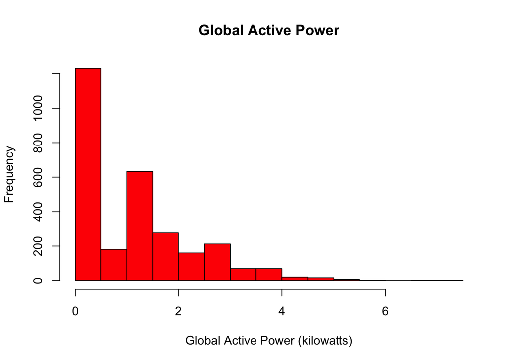

```r
# Plot 1
source("plot1.R")
plot1(data_sub)
```

```r
# Save the plot
dev.copy(png, "plot1.png", width = 480, height = 480)
```

### Plot 2

Our goal is to examine how `Global Active Power` varies over a 2-day period in February, 2007 on Thursday, Friday, and Saturday.

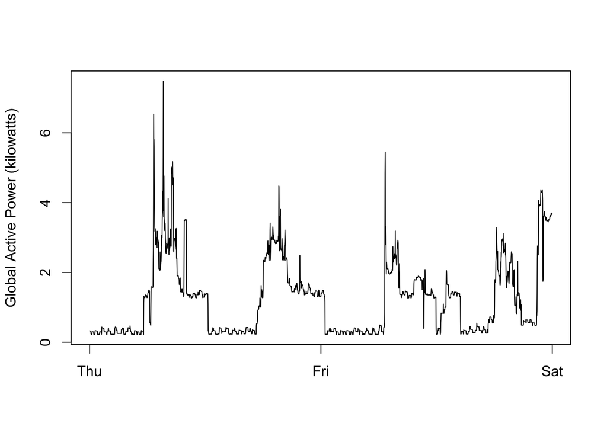

```r
# Plot 2
# Plot a line graph of Global Active Power over the 2-day period
# Combine the Date and Time variables to create a single Date/Time variable
source("plot2.R")
plot2(data_sub)
```

```r
dev.copy(png, "plot2.png", width = 480, height = 480)
```

### Plot 3

Our goal is show Energy Sub Metering over the 2-day period in February, 2007 factored by sub metering type.

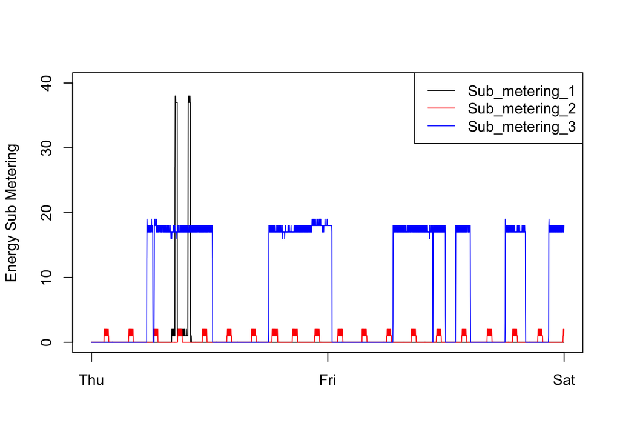

```r
# Plot 3
source("plot3.R")
plot3(data_sub)
```

```r
dev.copy(png, "plot3.png", width = 480, height = 480)
```

### Plot 4

The goal is to plot a 2 x 2 grid of plots showing the following: - Plot 2 in the upper left corner - A new plot containing `Voltage` vs `DateTime` in the upper right corner - Plot 3 in the lower left corner - A new plot containing `Global Reactive Power` vs `DateTime` in the lower right corner

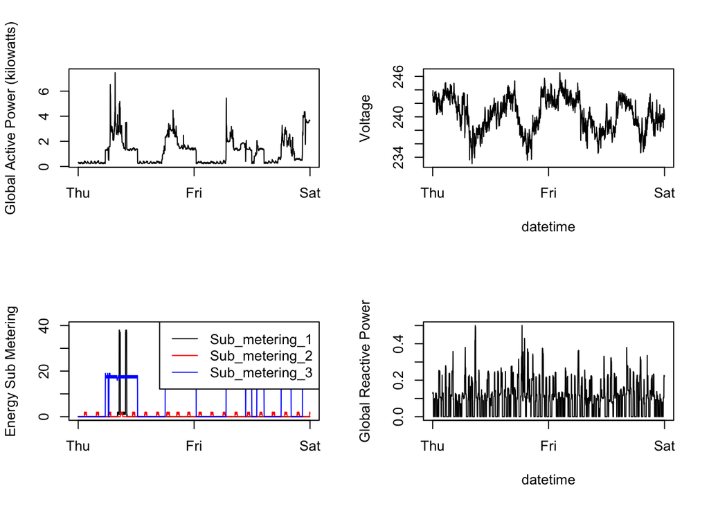

```r
# Plot 4
source("plot4.R")
plot4(data_sub)
```

```r
dev.copy(png, "plot4.png", width = 480, height = 480)
```